# Sectoral AI adoption and its effects on employment and economic output in EU

Anna Kędzierska-Głodek

2025-06-09

FINAL PAPER FOR ADVANCED ECONOMETRICS COURSE

DATA SCIENCE AND BUSINESS ANALYTICS 2024/2025

UNIVERSITY OF WARSAW, FACULTY OF ECONOMIC SCIENCES

# 1 Abstract

This analysis examines the impact of AI adoption in enterprises on employment rates and economic performance in European Union (EU) countries, recognizing the significant implications of AI for economic structures and employment dynamics. The primary objective is to understand how higher AI adoption in enterprises in EU countries affects the employment rate of people aged 20–64, assuming that AI technologies complement human labour and create new employment opportunities. A secondary objective is to investigate whether this relationship exhibits gender-specific effects, hypothesizing a stronger positive impact on female employment rates compared to male. The research addresses the urgent economic problem of managing the disruptive consequences of AI while harnessing its benefits, especially given the uncertainty surrounding its full impact and transitional challenges. The methodology employs a general-to-specific modelling approach using a panel dataset covering the 27 EU countries from 2021–2024. Regarding the main hypothesis (H1), the analysis established a robust modelling framework for assessing AI’s impact on overall employment, consistently identifying panel and random effects. For the secondary hypothesis (H2), the results are mixed and very nuanced, indicating a complex and sector-specific relationship between AI adoption and gender-specific employment rates. While some sectors, such as water supply, sewerage, waste management, and information and communication showed a stronger positive and statistically significant effect of AI adoption on female employment rates, supporting H2, other sectors contradicted this. Specifically, the AI hiring index, manufacturing, and professional, scientific and technical activities showed a negative effect, which was stronger for female employment. These results underline the need for targeted policies that address gender-specific challenges and employment opportunities arising from the adoption of AI across sectors.

# 2 Introduction

Analysing AI adoption and its impact on labour market outcomes is critical because of its implications for economic structures and employment dynamics across sectors. AI technologies have introduced significant disparities in job creation and replacement, as some industries experience automation that makes some roles obsolete while creating new opportunities in emerging fields. Understanding these changes is essential for policymakers to develop strategies to mitigate negative impacts, particularly in low-skilled sectors where job losses are most evident. Also, integrating AI has potential to increase productivity and economic growth, although it comes with the risk of increasing inequality. As companies across sectors, including healthcare and finance, increasingly adopt AI, analysing sector-specific challenges and successes becomes crucial to supporting effective workforce transitions and reskilling initiatives. Therefore, this topic presents urgent economic problem that requires multifaceted solutions to harness benefits of AI while addressing its disruptive consequences. [1,2,3,4,5]

## 2.1 Description Of the Problem

The problem of sectoral AI adoption and its impact on employment and economic output in the European Union is multi-faceted due to uncertainty about the full scope of AI’s impact, significant transitional challenges, and the complexity of developing adaptive policy frameworks and supporting social acceptance.

Key aspects of this problem include:

- Uncertain and dual impacts on employment. AI revolution is in its early stages and is still evolving, presenting both the potential to replace jobs and create new employment opportunities. There is no clear consensus in the existing literature on whether AI will ultimately lead to net job losses or gains. Sectors traditionally dependent on manual labour are identified as most vulnerable to job replacement. [1,2]
- Transitional challenges and skills gaps. Current phase of AI adoption is characterized by transitional challenges, where AI-driven economic growth does not immediately translate into widespread job creation. A key issue is the need for adaptive policies and education systems to prepare the workforce for these changes. Therefore, effective reskilling and upskilling programs are key interventions to mitigate the negative impacts and equip workers for new AI-enabled roles. [2,4]
- Regulatory and policy ambiguity in the EU context. The European Union faces particular challenges in establishing a comprehensive AI policy framework. There are significant geographical differences in regulatory approaches to AI around the world. A key issue is ensuring “privacy by design” in the technological infrastructure and clearly defining responsibilities, liabilities and culpability among human and AI stakeholders. [5]
- Impact on economic outcomes and the potential for increasing inequality. While AI offers significant potential for increasing productivity, there is a significant risk of deepening existing inequalities if the economic benefits of AI are not shared widely across society. [2,4,5]
- Implementation barriers and trust. In addition to policy and skills, there are fundamental barriers to practical AI implementation. “Lack of integration” with existing systems, difficulties with “information sharing,” and the broader need to “promote standards” and “build capacity” in the AI ecosystem. [2,5]

## 2.2 Research Hypotheses

Based on the literature the following hypotheses are worth testing.

**Main Hypothesis (H1):** Higher levels of enterprise AI adoption in EU countries lead to increased employment rates in the 20-64 age group, as AI technologies complement human labour and create new job opportunities rather than displacing workers.

**Secondary Hypothesis (H2):** The relationship between AI adoption and employment exhibits gender-specific effects, with AI adoption having a stronger positive impact on female employment rates compared to male employment rates in EU countries.

# 3 Literature Review

## 3.1 Main Hypothesis (H1)

The core of this hypothesis addresses the dual possibilities presented by AI: job displacement versus the creation of new employment opportunities [1,2]. Several sources support the potential for AI to lead to net job creation or a positive correlation with employment rates:

- Empirical analysis, specifically regression analysis of data from 2012 to 2022, suggests that AI development generally has a negative correlation with unemployment rates, implying that increased AI adoption can be linked to lower unemployment levels [1].
- The popularity of the term “Artificial Intelligence”, as measured by Google Trends data, correlates with job creation. This indicates that high public interest can drive investments in AI-driven enterprises, fostering job growth [1].
- AI integration has the potential to enhance productivity and stimulate economic growth. This broader economic benefit can contribute to overall employment growth by fostering a more dynamic and expanding economy [1,2,3].
- Specific industry implications show increased job creation in the information technology and consumer goods sectors, illustrating a clear trend of job growth in industries with rapid AI adoption. This suggests that AI can act as a catalyst for job creation in specific domains [1,5].
- In developed economies where AI adoption is higher, there is evidence of falling unemployment rates, suggesting that AI can generate new roles as quickly as it makes old ones obsolete. This view is consistent with the idea that AI can complement human work rather than completely replace it [1,2].
- While AI adoption and innovation may initially pose challenges leading to job losses, strategic AI implementation significantly mitigates these negative effects and improves employment conditions in the long term. This suggests that this relationship is complex and dependent on policy and strategic choices [2].

## 3.2 Secondary Hypothesis (H2)

Despite that cited sources do not provide direct findings supporting a stronger positive impact on female employment, they indicate that the gendered impact of AI adoption on employment is a key area of active research and analysis. Few sources address the intersection of AI/automation and gender in the labour market. Discussions include gender as a potential dimension of inequalities, requiring research on whether the benefits of AI are broadly distributed across socioeconomic groups [1,2,3]. Thus, considering gender as a variable affecting the labour market in the context of AI makes this a valid hypothesis.

# 4 Data

## 4.1 Datasets Overview

1. **AI Hiring Index Data**(data.csv):
- Source: OECD.AI – LinkedIn-based AI hiring trends
- Coverage: 47 countries, monthly data for years 2018-2025 → monthly data for years 2021-2024 transformed to annual means
- Selected variables: Country, ref_date, Relative_AI_hiring_index_pct
- Key variable: AI hiring intensity index – ratio of AI talent hiring relative to overall hiring of LinkedIn members per country 12-month moving average going back from December
2. [**EU Employment Data**](https://ec.europa.eu/eurostat/databrowser/view/lfsi_emp_a__custom_16965495/default/table?lang=en) (estat_lfsi_emp_a_filtered_en.csv):
- Source: Eurostat – Labour Force Survey
- Coverage: 27 EU countries, annual 2021-2024
- Selected variables: sex, geo, TIME_PERIOD, OBS_VALUE
- Key variable: employment percentage of total population
3. [**Labour productivity and unit labour costs by industry**](https://ec.europa.eu/eurostat/databrowser/view/nama_10_lp_a21__custom_17009168/default/table?lang=en) (estat_nama_10_lp_a21_filtered_en.csv):
- Source: Eurostat
- Coverage: 27 EU countries, annual 2021-2024
- Selected variables: nace_r2, geo, TIME_PERIOD, OBS_VALUE
- Key variable: real labour productivity per hour worked (percentage change on previous period)
4. [**EU GDP Data**](https://ec.europa.eu/eurostat/databrowser/view/namq_10_gdp__custom_16967648/default/table?lang=en) (estat_namq_10_gdp_filtered_en-3.csv):
- Source: Eurostat – National Accounts
- Coverage: EU countries, quarterly data for years 2021-2024 → quarterly data for years 2021-2024 transformed to annual means
- Selected variables: geo, TIME_PERIOD, OBS_VALUE
- Key variable: contribution to GDP growth in percentage point change compared to same period in previous year
5. [**EU AI Adoption Data**](https://ec.europa.eu/eurostat/databrowser/view/isoc_eb_ain2__custom_16968355/default/table?lang=en) (estat_isoc_eb_ain2_filtered_en-6.csv):
- Source: Eurostat – Information Society Statistics
- Coverage: 27 EU countries, annual data for years 2021-2024, 9 sectors, 2 information society indicators (actually 3 but 2 were combined into 1 – description below)
- Selected variables: nace_r2, indic_is, geo, TIME_PERIOD, OBS_VALUE
- Key variable: percentage of enterprises
- Information society indicators E_AI_PANY (data only for 2021) and E_AI_1PANY (data only for 2023-2024) combined into 1 variable E_AI_PANY (due to majority of the same purposes **covered by both indicators**; the rest indicators which are not included in the other dataset contain data in the periods as E_AI_PANY or E_AI_1PANY):
  - E_AI_PANY – enterprises using AI technologies for at least one of the purposes:
  1. **E_AI_PMS – marketing or sales**
  2. **E_AI_PPP – production processes**
  3. **E_AI_PBA – for organisation of business administration processes**
  4. **E_AI_PME – for management of enterprises**
  5. **E_AI_PLOG – logistics**
  6. **E_AI_PITS – ICT security**
  7. E_AI_PHR – for human resources management or recruiting
  - E_AI_1PANY – enterprises using AI technologies for at least one of the purposes:
  1. **E_AI_PMS – marketing or sales**
  2. **E_AI_PPP – production processes**
  3. **E_AI_PBAM – organisation of business administration processes or management**
  4. **E_AI_PLOG – logistics**
  5. **E_AI_PITS – ICT security**
  6. E_AI_PFIN – accounting, controlling or finance management
  7. E_AI_PRDI – research and development (R&D) or innovation activity
- E_AI_TANY – enterprises use at least one of the AI technologies:
  - AI_TTM – performing analysis of written language (text mining)
  - AI_TSR – converting spoken language into machine-readable format (speech recognition)
  - AI_TNLG – generating written or spoken language (natural language generation)
  - AI_TIR – identifying objects or persons based on images (image recognition, image processing)
  - AI_TML – use machine learning (e.g. deep learning) for data analysis
  - AI_TPA – use AI technologies automating different workflows or assisting in decision making (AI based software robotic process automation)
  - AI_TAR – use AI technologies enabling physical movement of machines via autonomous decisions based on observation of surroundings (autonomous robots, self-driving vehicles, autonomous drones)

### 4.1.1 Processing Steps Applied

1. Time alignment – restricted analysis to 2021-2024 period where all datasets overlap
2. Country matching – excluded non-EU countries from AI hiring data
3. Calculate mean of 2021 and 2023 values for missing AI adoption data for 2022
4. Adding mean for each indicator_sector variable
5. Join all tables to cover 27 EU countries, annual 2021-2024 dataset

#### 4.1.1.1 AI hiring data

```
## AI Hiring - Original dimensions: 4042 rows, 3 columns
```

```
## AI Hiring - Preprocessed dimensions: 96 rows, 3 columns
```

```
## # A tibble: 96 × 3
##    country  year ai_hiring_index
##    <chr>   <dbl>           <dbl>
##  1 Austria  2021           11.8
##  2 Austria  2022            1.56
##  3 Austria  2023            4.80
##  4 Austria  2024           12.9
##  5 Belgium  2021           10.0
##  6 Belgium  2022            3.47
##  7 Belgium  2023            7.73
##  8 Belgium  2024            9.80
##  9 Cyprus   2021            4.71
## 10 Cyprus   2022           12.1
## # ℹ 86 more rows
```

```
## Unique countries in AI Hiring dataset: 24
```

#### 4.1.1.2 Employment data

```
## Employment - Original dimensions: 405 rows, 12 columns
```

```
## Employment - Preprocessed dimensions: 108 rows, 6 columns
```

```
## # A tibble: 108 × 6
##    country   year emp_rate_female emp_rate_male emp_rate_Total emp_gender_gap
##    <chr>    <int>           <dbl>         <dbl>          <dbl>          <dbl>
##  1 Austria   2021            71.3          79.9           75.6           8.60
##  2 Austria   2022            73.4          81.2           77.3           7.8
##  3 Austria   2023            73.3          81.1           77.2           7.8
##  4 Austria   2024            73.9          80.8           77.4           6.90
##  5 Belgium   2021            66.8          74.5           70.6           7.7
##  6 Belgium   2022            68.1          75.7           71.9           7.60
##  7 Belgium   2023            68.3          75.9           72.1           7.60
##  8 Belgium   2024            68.3          76.3           72.3           8
##  9 Bulgaria  2021            69.1          77.5           73.3           8.40
## 10 Bulgaria  2022            72.1          79.6           75.9           7.5
## # ℹ 98 more rows
```

```
## Unique countries in employment dataset: 27
```

#### 4.1.1.3 Labour productivity per hour worked

```
## Productivity - Original dimensions: 1360 rows, 21 columns
```

```
## Productivity - Preprocessed dimensions: 108 rows, 17 columns
```

```
## # A tibble: 108 × 17
##    country   year  pc_A  pc_B  pc_C  pc_D  pc_E  pc_F  pc_G  pc_H  pc_I  pc_J  pc_K  pc_M  pc_N  pc_R  pc_S
##    <chr>    <int> <dbl> <dbl> <dbl> <dbl> <dbl> <dbl> <dbl> <dbl> <dbl> <dbl> <dbl> <dbl> <dbl> <dbl> <dbl>
##  1 Austria   2021   5.8  24.3   5.6  -4.3  -9.7 -11    -3.1  -4.6 -19.3   2     9.5  -0.3  -2.8  -3     9.2
##  2 Austria   2022   9.7 -12.6   5.1   7.1  -2.5  -3.7  -3.2  10.8  36.6   1.9   7.7   7.9   3.1  26.2   2.4
##  3 Austria   2023   6.1 -28.6  -2.6   5.8  -0.7  -6.9  -5.7  -2.4   2    -2.1  -6.6  -3.1   1.4   3.9  -3.8
##  4 Austria   2024   5.8  NA    -4.3  NA    NA    -1.7  NA    NA    NA     1.9   4.3  NA    NA    NA    NA
##  5 Belgium   2021  -0.3   4.6 -10.5 -10.8  -0.2  -2.1   4.1  -0.8   4.4   1.9   3.1  -2.8  -3.2   6.9  -7.5
##  6 Belgium   2022   1.8  -9.7   9.9 -32.3   1    -4.4   2.9  -1.5  -8.9   0.5  -5.8   0.1  -4.9   1.1  -6.2
##  7 Belgium   2023   2.7  -9.1  -1.1  11.6  -0.7  -1.5   0.5  -1     6.1   0.3   2.1  -2.3  -1.1  -1.9   2.5
##  8 Belgium   2024   3.5  NA     0.3  NA    NA     0.9  NA    NA    NA     3.8   3.4  NA    NA    NA    NA
##  9 Bulgaria  2021  38.6 -13.5   0.3  41   -21.1 -12.2   9.4   6.4  43.7  -2.2  25    12.6  13.9 -12.7   2
## 10 Bulgaria  2022  -3.5 -11.2  26.6  -8.3  20.4   7.2  -7.6  10.3  11.2  -4     7.5   0.8   2.9  12   -22.8
## # ℹ 98 more rows
```

```
## Unique countries in productivity dataset: 27
```

#### 4.1.1.4 GDP data

```
## GDP - Original dimensions: 400 rows, 11 columns
```

```
## GDP - Preprocessed dimensions: 100 rows, 3 columns
```

```
## # A tibble: 100 × 3
##    country   year gdp_growth
##    <chr>    <dbl>      <dbl>
##  1 Austria   2021      5.28
##  2 Austria   2022      5.44
##  3 Austria   2023     -0.835
##  4 Austria   2024     -1.34
##  5 Belgium   2021      6.43
##  6 Belgium   2022      4.28
##  7 Belgium   2023      1.21
##  8 Belgium   2024      1.02
##  9 Bulgaria  2021      7.42
## 10 Bulgaria  2022      4.13
## # ℹ 90 more rows
```

```
## Unique countries in gdp dataset: 25
```

#### 4.1.1.5 AI adoption data

```
## AI Adoption - Original dimensions: 1458 rows, 23 columns
```

```
## AI Adoption - Preprocessed dimensions: 108 rows, 20 columns
```

```
## # A tibble: 108 × 20
##    country   year AI_PANY_C AI_TANY_C AI_PANY_E AI_TANY_E AI_PANY_F AI_TANY_F AI_PANY_G AI_TANY_G AI_PANY_H
##    <chr>    <int>     <dbl>     <dbl>     <dbl>     <dbl>     <dbl>     <dbl>     <dbl>     <dbl>     <dbl>
##  1 Austria   2021      9.06      9.61      5.33      5.33      2.2       3.12      5.94      6.94      6.16
##  2 Austria   2022     10.3      11.0       6.24      6.24      3.16      3.7       7.03      7.64      7.2
##  3 Austria   2023     11.6      12.3       7.16      7.16      4.11      4.28      8.12      8.35      8.24
##  4 Austria   2024     21.9      22.7      17.8      17.8       7.19      7.35     14.9      15.7      12.8
##  5 Belgium   2021      7.46     10.4       4.66      8.83      4.81      8.3       5.55      8.08      5.12
##  6 Belgium   2022      9.59     12.9      NA        NA         4.32      6.74      5.8       9.16      7.52
##  7 Belgium   2023     11.7      15.3      NA        NA         3.83      5.17      6.05     10.2       9.92
##  8 Belgium   2024     18.0      23.2      NA        NA         8.25     11.1      17.1      22.5      20.5
##  9 Bulgaria  2021      1.87      2.88     NA        NA        NA         1.47      1.31      2.47      1.16
## 10 Bulgaria  2022      1.70      2.72     NA        NA        NA        NA         1.36      2.49      1.11
## # ℹ 98 more rows
## # ℹ 9 more variables: AI_TANY_H <dbl>, AI_PANY_I <dbl>, AI_TANY_I <dbl>, AI_PANY_J <dbl>, AI_TANY_J <dbl>,
## #   AI_PANY_M <dbl>, AI_TANY_M <dbl>, AI_PANY_N <dbl>, AI_TANY_N <dbl>
```

```
## Unique countries in ai_adoption dataset: 27
```

## 4.2 Panel Structure

This chapter provides the overview of panel dataset and includes visualizations to illustrate key aspects of the data. Table 4.2-1 describe structure of dataset, which covers 27 EU countries over four years, from 2021 to 2024. The dataset comprises 108 total observations. The analysis includes data for 9 sectors represented by 2 indicators: E_AI_PANY and E_AI_TANY. The dataset also incorporates other variables such as Productivity in sectors, GDP growth, AI_PANY_MEAN, and AI_TANY_MEAN. In total, there are 41 variables in the dataset (Table 4.2-2). The data completeness stands at 91.1%, with 4034 valid observations out of 4428 total, indicating 394 missing values (Table 4.2-3), which results in an unbalanced panel.

TABLE 4.2-1 PANEL STRUCTURE

Attribute

Details

**Total Ob servations**

108

- *Countries**

27 EU countries: AT, BE, BG, CY, CZ, DE, DK, EE, EL, ES, FI, FR, HR, HU, IE, IT, LT, LU, LV, MT, NL, PL, PT, RO, SE, SI, SK

**Time Coverage**

2021-2024 (4 years)

**Sectors**

**(NACE Rev. 2)**

9 sectors:

- C: Manufacturing
- E: Water supply; sewerage, waste management
- F: Construction
- G: Wholesale and retail trade
- H: Transportation and storage
- I: Accommodation and food service activities
- J: Information and communication
- M: Professional, scientific and technical activities
- N: Administrative and support service activities

**Indicators**

2 indicators:

- E_AI_PANY
- E_AI_TANY

**Additional variables**

Productivity in sectors, GDP growth, AI_PANY_MEAN, AI_TANY_MEAN

**Number of variables**

41

**Data Co mpleteness**

91.1% (4034 valid / 4428 total; 394 missing) – unbalanced

TABLE 4.2-2 Panel Data Statistics

```
##
## ==========================================================
## Statistic        N    Mean   St. Dev.      Min       Max
## ----------------------------------------------------------
## emp_rate_female 108  71.827    6.575     52.700    80.900
## emp_rate_male   108  80.689    3.999     72.400    89.000
## emp_rate_total  108  76.289    4.853     62.600    83.500
## emp_gender_gap  108  8.862     5.038      0.200    21.000
## ai_hiring_index 96   9.830     7.433     -5.671    35.545
## ai_pany_c       108  6.678     4.341      0.990    21.900
## ai_tany_c       108  8.889     5.817      1.280    27.280
## ai_pany_e       76   4.389     4.312      0.000    17.770
## ai_tany_e       81   6.597     5.832      0.000    24.770
## ai_pany_f       99   2.878     2.085      0.020    10.100
## ai_tany_f       106  4.496     3.478      0.050    19.080
## ai_pany_g       105  6.179     4.440      0.540    20.780
## ai_tany_g       108  8.190     5.677      0.600    27.340
## ai_pany_h       104  5.509     3.674      0.210    20.540
## ai_tany_h       108  7.324     4.846      0.310    23.030
## ai_pany_i       101  3.035     2.641      0.000    15.580
## ai_tany_i       106  4.299     3.397      0.060    16.850
## ai_pany_j       106  26.520   12.328      7.710    59.150
## ai_tany_j       104  31.850   14.219      8.120    68.300
## ai_pany_m       105  13.591    8.349      1.820    38.700
## ai_tany_m       105  17.835   10.909      3.670    53.710
## ai_pany_n       100  7.412     4.399      1.010    21.460
## ai_tany_n       108  9.566     5.811      1.570    27.840
## pc_a            108 -102.802 1,085.097 -11,273.700 94.800
## pc_b            78   -1.006   25.538     -76.800   86.400
## pc_c            108  1.303     6.821     -21.800   26.600
## pc_d            78   -5.546   28.015     -56.300   102.300
## pc_e            82   0.271    11.698     -25.900   26.900
## pc_f            108  -1.133    7.835     -26.600   31.600
## pc_g            82   0.190     7.485     -15.400   22.300
## pc_h            82   4.339    21.804     -29.900   185.800
## pc_i            82   10.449   19.608     -30.300   85.400
## pc_j            108  1.615     6.852     -17.800   26.100
## pc_k            108  2.006    10.508     -24.600   44.200
## pc_m            82   2.094     7.562     -12.600   35.000
## pc_n            82   3.172     7.750     -14.100   29.200
## pc_r            82   4.790    15.171     -49.300   61.800
## pc_s            82   2.982    23.106     -22.800   193.800
## gdp_growth      100  3.588     3.525     -5.572    15.875
## ai_pany_mean    108  8.867     4.846      1.881    25.760
## ai_tany_mean    108  11.083    6.034      2.296    28.244
## ----------------------------------------------------------
```

TABLE 4.2-3 Missing Data Summary

```
##
## Missing Data Summary
## ================================
##       variable     missing_count
## --------------------------------
## 1  ai_hiring_index      12
## 2     ai_pany_e         32
## 3     ai_tany_e         27
## 4     ai_pany_f          9
## 5     ai_tany_f          2
## 6     ai_pany_g          3
## 7     ai_pany_h          4
## 8     ai_pany_i          7
## 9     ai_tany_i          2
## 10    ai_pany_j          2
```

[output cut: 16 more lines]

### 4.2.1 Visualisations

Figure 1 illustrates average total employment rate by country from 2021-2024. On the Figure 2 we can see gender gap and on Figure 3 average employment rates: total and by gender for each year from panel dataset.

FIGURE 1 Average Total Employment Rate by Country (2021-2024)

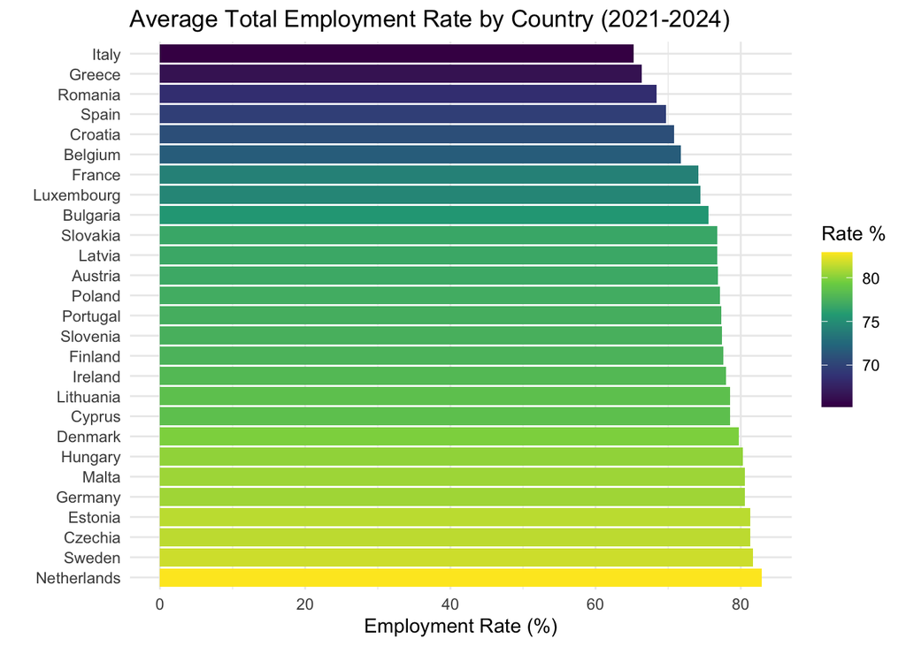

FIGURE 2 Average Gender Employment Gap by Country (2021-2024)

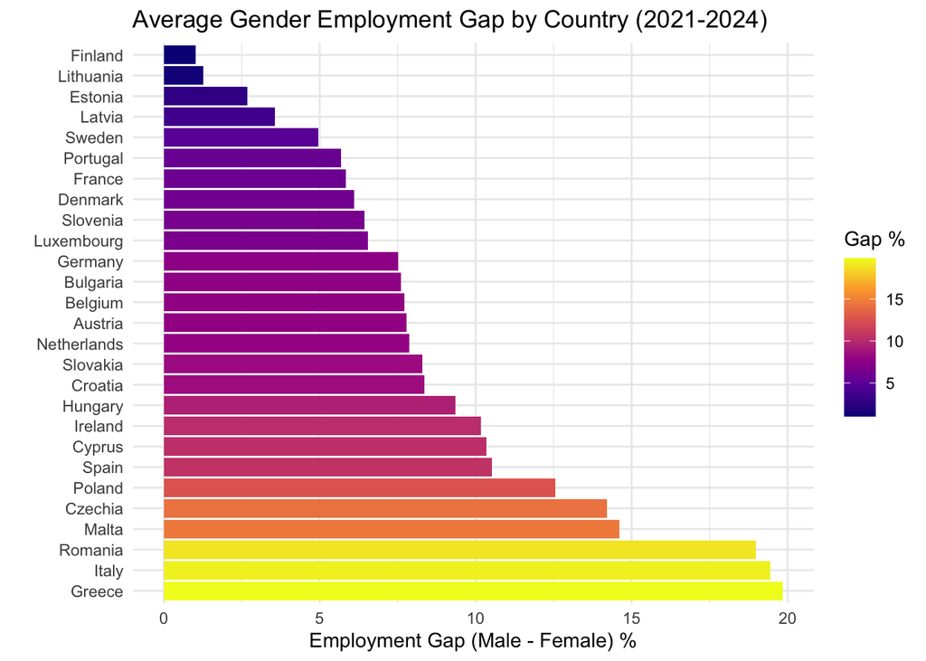

FIGURE 3 Average Employment Rates by Gender (2021-2024)

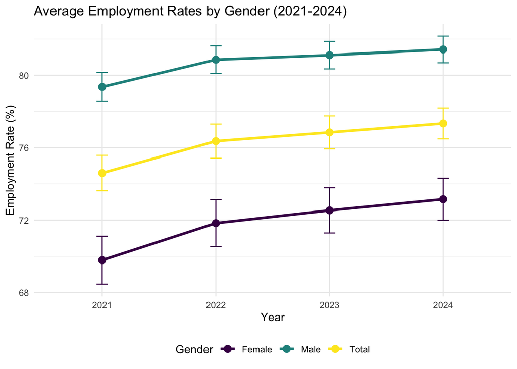

On the Figure 4 there is average hiring index for each year. While to 2023 it was dropping, it grew in 2024.

FIGURE 4 Average AI Hiring Index by Year

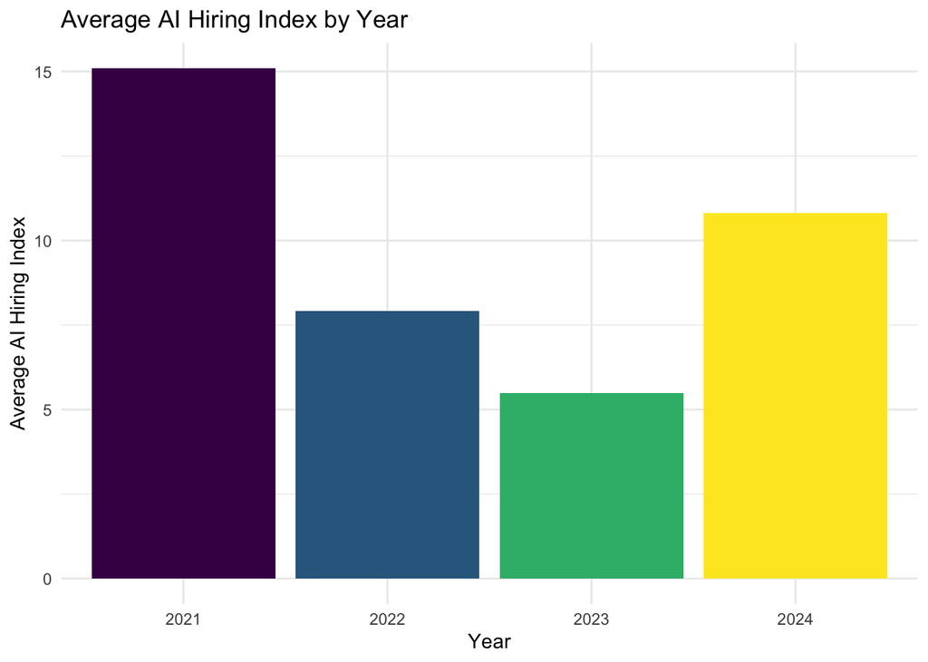

Figure 5 depict average AI adoption rates for both indicators: PANY and TANY. Both rates grow over time.

FIGURE 5 Average AI Adoption: PANY vs TANY

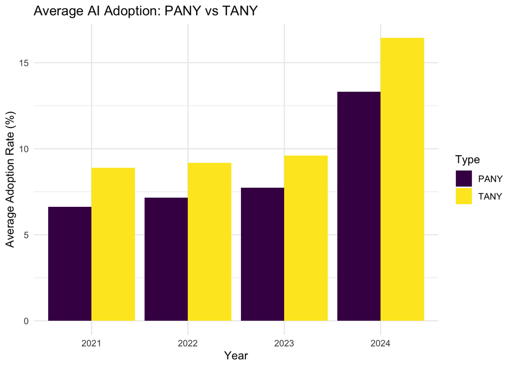

FIGURE 6 Average AI Adoption (PANY) by Sector

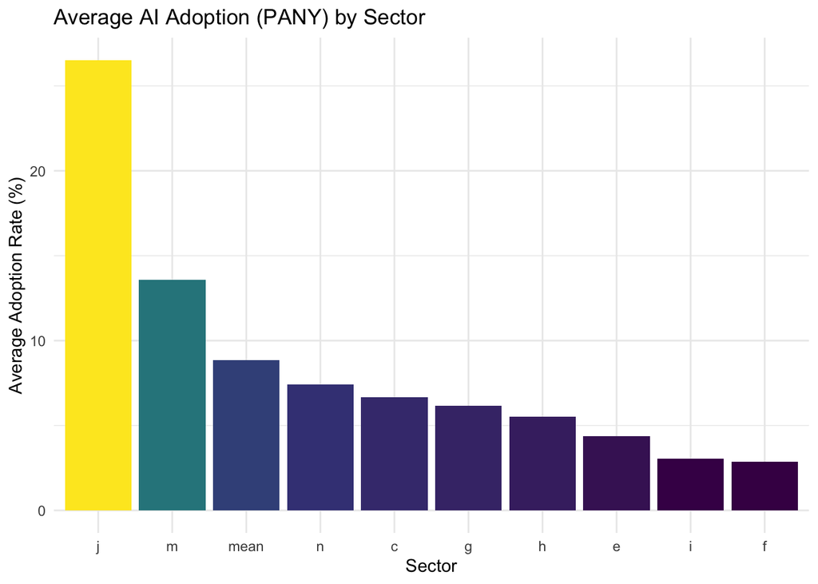

FIGURE 7 Average AI Adoption (TANY) by Sector

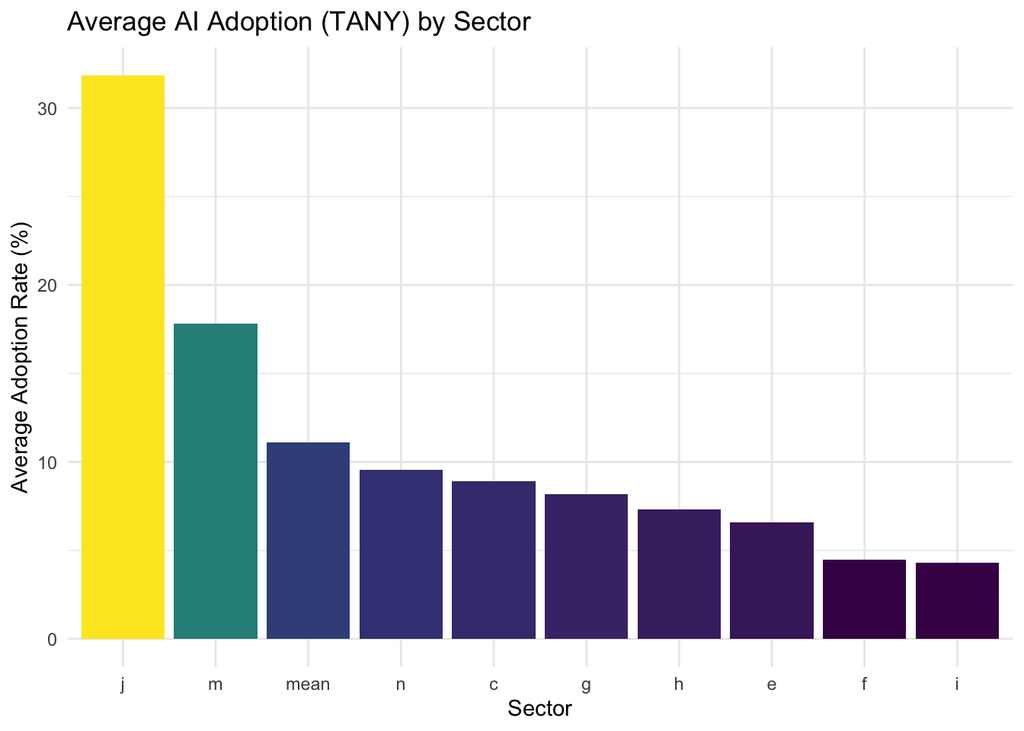

# 5 Method/Model

This chapter describes all steps performed during the analysis of panel dataset.

1. **General to specific approach** was performed starting with a comprehensive specification that includes all potential predictors.
2. **Model selection through sequential elimination** was performed. This process is based on Wald tests, which are used to ensure the validity of restrictions at each step of variable removal.
3. **Hypothesis testing** with different models were tested for both the Main Hypothesis (H1) and the Secondary Hypothesis (H2).
   - For Main Hypothesis (H1), which posits that higher AI adoption leads to increased employment rates in the 20-64 age group, various models (Model 1 to Model 6) were evaluated, including different combinations of AI adoption indicators (e.g., ai_pany_sectors, ai_tany_sectors) and their interactions with the ai_hiring_index.
   - For Secondary Hypothesis (H2), which suggests gender-specific employment effects with a stronger positive impact on female employment, models were specifically run with emp_rate_female and emp_rate_male as dependent variables, incorporating AI adoption indicators based on purpose (ai_pany_sectors) and technology (ai_tany_sectors).
4. **Hausman tests** were performed to determine the appropriate estimator for the panel data, specifically to choose between random effects (RE) or fixed effects (FE) models.
5. **Diagnostic tests** were performed for the final models:
   - F-test for individual effects (FE vs Pooled): used to determine if panel effects exist.
   - Breusch-Pagan test (RE vs Pooled): used to determine if random effects exist.
   - Breusch-Godfrey/Wooldridge test: used to check for autocorrelation in the residuals.
   - Studentized Breusch-Pagan test: used to check for heteroskedasticity in the residuals.
   - Pesaran CD test: used to assess cross-sectional dependence, with robust standard errors applied (clustered) when dependence was present.
6. **Variable significance** selection process identified insignificant variables at both 5% and 10% significance levels and their potential removal based on Wald tests.

The analysis aimed to progress from more general to specific models, ensuring that only statistically significant predictors were retained.

# 6 Results

The analysis of AI adoption’s effects on employment and economic output in the EU presents detailed results for both the main and secondary hypotheses, derived through a general-to-specific modelling approach. The general model includes AI adoption rate in all sectors and interactions of mean from all sectoral AI adoption rate and AI hiring index. Systematic variable elimination was validated by Wald tests and lead to preferred specification, which retains only statistically significant variables.

## 6.1 Main Hypothesis (H1)

Across the six models tested for H1 (Model 1 to Model 6), the Hausman tests primarily indicated the use of Random Effects (RE) models. Panel effects were found to exist across all models, as indicated by a p-value = 0 from the F-test for individual effects. Random effects were confirmed to exist across all models, with a p-value = 0 from the Breusch-Pagan test. Most models (Models 1-4) showed no autocorrelation, but Models 5 and 6 indicated the presence of autocorrelation. Heteroskedasticity was present in Models 1, 2, 3, and 6, while Model 4 showed homoskedasticity, and Model 5 was close to homoskedasticity (p=0.0505). Because of cross-sectional dependence for all models, robust standard errors (clustered) were applied. Process identified insignificant variables at 5% and 10% significance levels. However, at the first step, ai_hiring_index was eliminated. Next remaining variables which were insignificant at 10% were eliminated. Model 3 and 6 have all significant variables.

Table 6.1‑1 SUMMARY OF MODEL RESULTS (DEPENDENT VARIABLE: EMP_RATE_TOTAL)

- *Test**

**M odel1**

**M odel2**

**M odel3**

**M odel4**

**M odel5**

**M odel6**

**Fo rmula**

emp_rat e_total ~ **ai_hi ring_in dex** + ai_p any_c + ai_p any_e + ai_p any_f + ai_p any_g + ai_p any_h + ai_p any_i + ai_p any_j + ai_p any_m + ai_p any_n + ai_pany _mean:a i_hirin g_index

emp_rat e_total ~ ai_p any_c + ai_p any_e + ai_pan y_f** + ai_p any_g + ai_pan y_h** + ai_pan y_i** + ai_p any_j + ai_p any_m + ai_p any_n + ai_pany _mean:a i_hirin g_index

emp_rat e_total ~ ai_p any_c + ai_p any_e + ai_p any_g + ai_p any_j + ai_p any_m + ai_p any_n + ai_pany _mean:a i_hirin g_index

emp_rat e_total ~ **ai_hi ring_in dex** + ai_t any_c + ai_t any_e + ai_t any_f + ai_t any_g + ai_t any_h + ai_t any_i + ai_t any_j + ai_t any_m + ai_t any_n + ai_tany _mean:a i_hirin g_index

emp_rat e_total ~ ai_t any_c + ai_t any_e + ai_tan y_f** + ai_t any_g + ai_tan y_h** + ai_tan y_i** + ai_t any_j + ai_t any_m + ai_t any_n + ai_tany _mean:a i_hirin g_index

emp_rat e_total ~ ai_t any_c + ai_t any_e + ai_t any_g + ai_t any_j + ai_t any_m + ai_t any_n + ai_tany _mean:a i_hirin g_index

**Model Type**

RE

RE

RE

FE

RE

RE

- *F-test for ind ividual effects FE vs P ooled**

p = 0 .0000*

p = 0 .0000*

p = 0 .0000*

p = 0 .0000*

p = 0 .0000*

p = 0 .0000*

**In terpret ation**

Panel effects exist

Panel effects exist

Panel effects exist

Panel effects exist

Panel effects exist

Panel effects exist

- *Breusc h-Pagan test RE vs P ooled**

p = 0 .0000*

p = 0 .0000*

p = 0 .0000*

p = 0 .0000*

p = 0 .0000*

p = 0 .0000*

**In terpret ation**

Random effects exist

Random effects exist

Random effects exist

Random effects exist

Random effects exist

Random effects exist

**Hausman test RE vs FE**

p = 0.6490

p = 0.4770

p = 0.2552

p = 0 .0002*

p = 0.9998

p = 0.7014

**In terpret ation**

Use Random Effects

Use Random Effects

Use Random Effects

Use Fixed Effects

Use Random Effects

Use Random Effects

**Wald test for v ariable re moval**

p = 0 .4108*

p = 0 .4108*

p = 0 .8869*

p = 0 .8869*

**In terpret ation**

Removal ju stified

Removal ju stified

Removal ju stified

Removal ju stified

**Breus ch-Godf rey/Woo ldridge test Serial Correl ation**

p = 0.1800

p = 0.1913

p = 0.1648

p = 0.7724

p = 0 .0213*

p = 0 .0352*

**In terpret ation**

No a utocorr elation

No a utocorr elation

No a utocorr elation

No a utocorr elation

A utocorr elation present

A utocorr elation present

**Stud entized Breusc h-Pagan test Hetero skedast icity**

p = 0 .0482*

p = 0 .0114*

p = 0 .0230*

p = 0.2088

p = 0.0505

p = 0 .0162*

**In terpret ation**

Hete roskeda sticity present

Hete roskeda sticity present

Hete roskeda sticity present

Ho moskeda sticity

Ho moskeda sticity

Hete roskeda sticity present

**Pesaran CD test C ross-se ctional Depen dence**

p = 0 .0000*

p = 0 .0000*

p = 0 .0000*

p = 0 .0000*

p = 0 .0000*

p = 0 .0000*

**In terpret ation**

Cros s-sect. dep. p resent. Robust SEs applied Cl ustered

Cros s-sect. dep. p resent. Robust SEs applied Cl ustered

Cros s-sect. dep. p resent. Robust SEs applied Cl ustered

Cros s-sect. dep. p resent. Robust SEs applied Cl ustered

Cros s-sect. dep. p resent. Robust SEs applied Cl ustered

Cros s-sect. dep. p resent. Robust SEs applied Cl ustered

- *Insign ificant va riables 5%**

ai *hiring *index, ai* pany_f, ai* pany_h, ai _pany_i

ai_ pany_f, ai_ pany_h, ai _pany_i

All sign ificant

ai *hiring *index, ai* tany_f, ai* tany_g, ai_ tany_h, ai_ tany_i, ai_ tany_n, ai_hiri ng_inde x:ai_ta ny_mean

ai_ tany_f, ai_ tany_g, ai_ tany_h, ai_ tany_i, ai _tany_n

ai _tany_n

- *Insign ificant va riables 10%**

ai *hiring *index, ai* pany_f, ai* pany_h, ai _pany_i

ai_ pany_f, ai_ pany_h, ai _pany_i

All sign ificant

ai *hiring *index, ai* tany_f, ai* tany_g, ai_ tany_h, ai_ tany_i, ai_hiri ng_inde x:ai_ta ny_mean

ai_ tany_f, ai_ tany_h, ai_ tany_i, ai _tany_n

All sign ificant

```
##
## Model Comparison: General to Specific
## ========================================================================================
##                                                  Dependent variable:
##                              -----------------------------------------------------------
##                                                          emp
##                               Model 1   Model 2   Model 3   Model 4   Model 5   Model 6
##                                 (1)       (2)       (3)       (4)       (5)       (6)
## ----------------------------------------------------------------------------------------
## ai_hiring_index               -0.017                        -0.035
##                               (0.020)                       (0.025)
## ai_pany_c                    -0.464*** -0.480*** -0.416***
##                               (0.148)   (0.151)   (0.115)
## ai_pany_e                     0.170**   0.170**   0.166**
##                               (0.070)   (0.069)   (0.072)
## ai_pany_f                      0.231     0.241
##                               (0.223)   (0.222)
## ai_pany_g                    0.380***  0.373***  0.458***
##                               (0.119)   (0.120)   (0.124)
## ai_pany_h                     -0.047    -0.027
##                               (0.195)   (0.195)
## ai_pany_i                      0.032     0.056
##                               (0.121)   (0.118)
## ai_pany_j                    0.105***  0.112***  0.101***
##                               (0.032)   (0.030)   (0.027)
## ai_pany_m                    -0.227*** -0.229*** -0.185***
##                               (0.066)   (0.067)   (0.054)
## ai_pany_n                    0.229***  0.236***  0.199***
##                               (0.074)   (0.073)   (0.069)
## ai_hiring_index:ai_pany_mean -0.008**
##                               (0.004)
## ai_pany_mean:ai_hiring_index           -0.011*** -0.010***
##                                         (0.003)   (0.002)
## ai_tany_c                                                  -0.298*** -0.282*** -0.252***
##                                                             (0.094)   (0.092)   (0.082)
## ai_tany_e                                                  0.232***  0.207***  0.215***
##                                                             (0.069)   (0.076)   (0.078)
## ai_tany_f                                                    0.133     0.073
##                                                             (0.143)   (0.142)
## ai_tany_g                                                    0.119    0.154*    0.191**
```

[output cut: 15 more lines]

```
## Constant                     74.834*** 74.622*** 74.289***           74.187*** 74.046***
##                               (1.404)   (1.373)   (1.140)             (1.305)   (1.189)
## ----------------------------------------------------------------------------------------
## Observations                    68        68        68        73        73        73
## R2                             0.831     0.827     0.833     0.635     0.817     0.815
## Adjusted R2                    0.798     0.797     0.814     0.343     0.788     0.795
## ========================================================================================
## Note:                        *p<0.1; **p<0.05; ***p<0.01
##                              Robust standard errors in parentheses
##                              Model 1 : Random Effects
##                              Model 2 : Random Effects
##                              Model 3 : Random Effects
##                              Model 4 : Fixed Effects
##                              Model 5 : Random Effects
##                              Model 6 : Random Effects
```

The analysis of the variable coefficients in Model 3 and 6 provides the following insights (Table 6.1-2).

Variables with a positive and significant impact on the total employment rate (emp_rate_total), supporting H1:

- Water supply; sewerage, waste management (ai_pany_e) for both showed a positive and statistically significant impact, for ai_tany_e (0.215), for ai_pany_e (0.166). This suggests that higher adoption of AI in sector E is associated with an increase in employment rates.
- Wholesale and retail trade (ai_pany_g) for both displayed a positive and statistically significant impact, for ai_pany_g (0.458), for ai_tany_g (0.191). This indicates a strong positive association between AI adoption in sector G and increased employment rates.
- Information and communication (ai_pany_j) have statistically significant positive impact, similar for both models ai_pany_j (0.101) and ai_tany_j (0.097). This also indicates a positive relationship with higher employment rates.
- Administrative and support service activities (ai_pany_n) for both models shows a positive association with increased employment rates for ai_pany_j (0.199) and ai_tany_j (0.070).

These findings support the part of Hypothesis H1 that AI complement human labour and create new job opportunities, leading to increased employment rates.

Variables with a negative and significant impact on the total employment rate (emp_rate_total), contradicting H1:

- Manufacturing for ai_pany_c (-0.416) and ai_tany_c (-0.252) indicate that higher AI adoption in sector C is associated with a decrease in employment rates.
- AI in professional, scientific and technical activities ai_pany_m (-0.185) and ai_pany_m (-0.092) suggests a negative relationship with employment rates.

These results do not support the overall premise of Hypothesis H1 that AI leads to increased employment. Instead, they suggest that certain forms of AI adoption may lead to job displacement or  
a negative influence on employment rates.

Table 6.1‑3 AI Adoption Impact on Employment Rates (using ai_pany and ai_tany indicators)

| **AI Adoption Indicator (Purpose of AI)** | **AI_PANY (Model 3)** | **AI_TANY (Model 6)** |
| --- | --- | --- |
| **ai_pany_c / ai_tany_c (AI in Manufacturing)** | -0.416 | -0.252 |
| **ai_pany_e / ai_tany_e (AI in Water supply; sewerage, waste management)** | 0.166 | 0.215 |
| **ai_pany_g / ai_tany_g (AI in Wholesale and retail trade)** | 0.458 | 0.191 |
| **ai_pany_j / ai_tany_j (AI in Information and communication)** | 0.101 | 0.097 |
| **ai_pany_m / ai_tany_m (AI in Professional, scientific and technical activities)** | -0.185 | -0.092 |
| **ai_pany_n / ai_tany_n (AI Administrative and support service activities)** | 0.199 | 0.070 |

## 6.2 Secondary Hypothesis (H2)

### 6.2.1 AI_HIRING_INDEX + AI_PANY_SECTORS

Table 6.2‑1 SUMMARY OF MODEL RESULTS (DEPENDENT VARIABLE: EMP_RATE_FEMALE AND EMP_RATE_MALE)

- *Test**

**M odel1**

**M odel2**

**M odel3**

**M odel4**

**M odel5**

**M odel6**

**Fo rmula**

e mp_rate *female ~ ai* hiring_ index + ai_p any_c + ai_p any_e + ai_p any_f + ai_p any_g + ai_p any_h + ai_p any_i + ai_p any_j + ai_p any_m + ai_p any_n + **ai *pany_m ean:ai* hiring_ index**

e mp_rate *female ~ ai* hiring_ index + ai_p any_c + ai_p any_e + ai_pan y_f** + ai _pany_g **+ ai_pan y_h** + ai_pan y_i** + ai_p any_j + ai_p any_m + ai _pany_n

e mp_rate *female ~ ai* hiring_ index + ai_p any_c + ai_p any_e + ai_p any_g + ai_p any_j + ai_p any_m + ai _pany_n

emp_ra te_male ~ ai_ hiring_ index + ai_p any_c + ai_p any_e + ai_p any_f + ai_p any_g + ai_p any_h + ai_p any_i + ai_p any_j + ai_p any_m + ai_p any_n + **ai *pany_m ean:ai* hiring_ index**

emp_ra te_male ~ ai_ hiring_ index + ai_p any_c + ai_p any_e + ai_pan y_f** + ai_p any_g + **ai_p any_h + ai_pan y_i** + ai_p any_j + ai_p any_m + ai _pany_n

emp_ra te_male ~ ai_ hiring_ index + ai_p any_c + ai_p any_e + ai_p any_g + ai_p any_j + ai_p any_m + ai _pany_n

**Model Type**

RE

RE

RE

RE

RE

RE

- *F-test for ind ividual effects FE vs P ooled**

p = 0 .0000*

p = 0 .0000*

p = 0 .0000*

p = 0 .0000*

p = 0 .0000*

p = 0 .0000*

**In terpret ation**

Panel effects exist

Panel effects exist

Panel effects exist

Panel effects exist

Panel effects exist

Panel effects exist

- *Breusc h-Pagan test RE vs P ooled**

p = 0 .0000*

p = 0 .0000*

p = 0 .0000*

p = 0 .0000*

p = 0 .0000*

p = 0 .0000*

**In terpret ation**

Random effects exist

Random effects exist

Random effects exist

Random effects exist

Random effects exist

Random effects exist

**Hausman test RE vs FE**

p = 0.9999

p = 0.5408

p = 0.9603

p = 0.1853

p = 0.9991

p = 0.9967

**In terpret ation**

Use Random Effects

Use Random Effects

Use Random Effects

Use Random Effects

Use Random Effects

Use Random Effects

**Wald test for v ariable re moval**

N/A

p = 0 .3284*

p = 0 .5646*

p = 0 .1588*

p = 0 .5787*

**In terpret ation**

Removal ju stified

Removal ju stified

Removal ju stified

Removal ju stified

**Breus ch-Godf rey/Woo ldridge test Serial Correl ation**

p = 0.1703

p = 0.2227

p = 0.1956

p = 0.1580

p = 0.2277

p = 0.3311

**In terpret ation**

No a utocorr elation

No a utocorr elation

No a utocorr elation

No a utocorr elation

No a utocorr elation

No a utocorr elation

**Stud entized Breusc h-Pagan test Hetero skedast icity**

p = 0 .0173*

p = 0 .0030*

p = 0 .0040*

p = 0.0591

p = 0.0613

p = 0 .0373*

**In terpret ation**

Hete roskeda sticity present

Hete roskeda sticity present

Hete roskeda sticity present

Ho moskeda sticity

Ho moskeda sticity

Hete roskeda sticity present

**Pesaran CD test C ross-se ctional Depen dence**

p = 0 .0000*

p = 0 .0000*

p = 0 .0000*

p = 0 .0000*

p = 0 .0000*

p = 0 .0000*

**In terpret ation**

Cros s-sect. dep. p resent. Robust SEs applied Cl ustered

Cros s-sect. dep. p resent. Robust SEs applied Cl ustered

Cros s-sect. dep. p resent. Robust SEs applied Cl ustered

Cros s-sect. dep. p resent. Robust SEs applied Cl ustered

Cros s-sect. dep. p resent. Robust SEs applied Cl ustered

Cros s-sect. dep. p resent. Robust SEs applied Cl ustered

- *Insign ificant va riables 5%**

ai *hiring *index, ai* pany_f, ai* pany_h, ai_ pany_i, ai_hiri ng_inde x:ai_pa ny_mean

ai_ pany_f, ai_ pany_h, ai _pany_i

All sign ificant

ai *hiring *index, ai* pany_f, ai* pany_h, ai_ pany_i, ai _pany_j

ai_ pany_f, ai_ pany_h, ai_ pany_i, ai _pany_j

ai _pany_j

- *Insign ificant va riables 10%**

ai *hiring *index, ai* pany_f, ai* pany_h, ai_ pany_i, ai_hiri ng_inde x:ai_pa ny_mean

ai_ pany_f, ai_ pany_h, ai _pany_i

All sign ificant

ai *hiring *index, ai* pany_f, ai* pany_h, ai _pany_i

ai_ pany_f, ai_ pany_h, ai_ pany_i, ai _pany_j

ai _pany_j

TABLE 6.2 2 MODEL COMPARISON (DEPENDENT VARIABLE: EMP_RATE_FEMALE AND EMP_RATE_MALE)

```
##
## Model Comparison: General to Specific
## ========================================================================================
##                                                  Dependent variable:
##                              -----------------------------------------------------------
##                                           emp                      emp_rate_male
##                               Model 1   Model 2   Model 3   Model 4   Model 5   Model 6
##                                 (1)       (2)       (3)       (4)       (5)       (6)
## ----------------------------------------------------------------------------------------
## ai_hiring_index               -0.029   -0.068*** -0.074***  -0.012   -0.055*** -0.055***
##                               (0.029)   (0.020)   (0.020)   (0.020)   (0.014)   (0.014)
## ai_pany_c                    -0.512*** -0.459*** -0.533*** -0.408*** -0.353**  -0.394***
##                               (0.167)   (0.164)   (0.126)   (0.157)   (0.160)   (0.106)
## ai_pany_e                     0.176**   0.177**   0.168**   0.173**   0.174**   0.149**
##                               (0.080)   (0.081)   (0.081)   (0.067)   (0.069)   (0.069)
## ai_pany_f                      0.273     0.284               0.182     0.187
##                               (0.253)   (0.252)             (0.201)   (0.201)
## ai_pany_g                    0.397***  0.388***  0.442***  0.373***  0.366***  0.403***
##                               (0.136)   (0.131)   (0.127)   (0.119)   (0.115)   (0.108)
## ai_pany_h                     -0.166    -0.274               0.056    -0.052
##                               (0.237)   (0.218)             (0.162)   (0.160)
## ai_pany_i                      0.068     0.002              -0.027    -0.096
##                               (0.144)   (0.147)             (0.123)   (0.130)
## ai_pany_j                    0.145***  0.128***  0.130***   0.057*     0.039     0.035
##                               (0.035)   (0.032)   (0.029)   (0.034)   (0.032)   (0.026)
## ai_pany_m                    -0.266*** -0.258*** -0.216*** -0.179*** -0.170*** -0.148***
##                               (0.071)   (0.072)   (0.061)   (0.066)   (0.064)   (0.050)
## ai_pany_n                    0.272***  0.252***  0.206***   0.178**   0.156**   0.144**
##                               (0.083)   (0.083)   (0.077)   (0.072)   (0.071)   (0.065)
## ai_hiring_index:ai_pany_mean  -0.007                       -0.008**
##                               (0.005)                       (0.003)
## Constant                     70.061*** 70.711*** 70.049*** 79.790*** 80.473*** 80.509***
##                               (1.857)   (1.716)   (1.500)   (1.106)   (1.054)   (0.973)
## ----------------------------------------------------------------------------------------
## Observations                    68        68        68        68        68        68
## R2                             0.763     0.759     0.758     0.881     0.878     0.864
## Adjusted R2                    0.717     0.717     0.730     0.857     0.857     0.848
## ========================================================================================
## Note:                        *p<0.1; **p<0.05; ***p<0.01
##                              Robust standard errors in parentheses
##                              Model 1 : Random Effects
##                              Model 2 : Random Effects
##                              Model 3 : Random Effects
##                              Model 4 : Random Effects
##                              Model 5 : Random Effects
##                              Model 6 : Random Effects
```

The analysis of the variable coefficients in Model 3 and 6 provides the following insights (Table 6.2-2).

Supporting H2:

- Water supply; sewerage, waste management (ai_pany_e) for both showed a positive and statistically significant impact, which was stronger for female employment (0.168) than male (0.149).
- Information and communication (ai_pany_j) have statistically significant positive impact for female employment (0.130), while it was not significant for male employment model.
- Administrative and support service activities (ai_pany_n) for both showed a positive and statistically significant impact, which was stronger for female employment (0.206) than male (0.144).

Table 6.2‑3 Comparison of AI Adoption Impact on Female vs. Male Employment Rates (using ai_pany indicators)

| **AI Adoption Indicator (Purpose of AI)** | **Impact on Female Employment (Model 3)** | **Impact on Male Employment (Model 6)** |
| --- | --- | --- |
| **ai_hiring_index (AI in hiring processes)** | -0.074 | -0.055 |
| **ai_pany_c (AI in Manufacturing)** | -0.533 | -0.394 |
| **ai_pany_e (AI in Water supply; sewerage, waste management)** | 0.168 | 0.149 |
| **ai_pany_g (AI in Wholesale and retail trade)** | 0.442 | 0.403 |
| **ai_pany_j (AI in Information and communication)** | 0.130 | 0 |
| **ai_pany_m (AI in Professional, scientific and technical activities)** | -0.216 | -0.148 |
| **ai_pany_n (AI Administrative and support service activities)** | 0.206 | 0.144 |

### 6.2.2 AI_HIRING_INDEX + AI_TANY_SECTORS

Table 6.2‑4 SUMMARY OF MODEL RESULTS (DEPENDENT VARIABLE: EMP_RATE_FEMALE AND EMP_RATE_MALE)

- *Test**

**M odel1**

**M odel2**

**M odel3**

**M odel4**

**M odel5**

**M odel6**

**Fo rmula**

e mp_rate *female ~ ai* hiring_ index + ai_t any_c + ai_t any_e + ai_t any_f + ai_t any_g + ai_t any_h + ai_t any_i + ai_t any_j + ai_t any_m + ai_t any_n + **ai *tany_m ean:ai* hiring_ index**

e mp_rate *female ~ ai* hiring_ index + ai_t any_c + ai_t any_e + **ai_t any_f + ai_t any_g + ai_t any_h + ai_tan y_i** + ai_t any_j + ai_t any_m + **ai_t any_n**

e mp_rate *female ~ ai* hiring_ index + ai_t any_c + ai_t any_e + ai_t any_g + ai_t any_j + ai _tany_m

emp_ra te_male ~ ai_ hiring_ index + ai_t any_c + ai_t any_e + ai_t any_f + ai_t any_g + ai_t any_h + ai_t any_i + ai_t any_j + ai_t any_m + ai_t any_n + **ai *tany_m ean:ai* hiring_ index**

emp_ra te_male ~ ai_ hiring_ index + ai_t any_c + ai_t any_e + **ai_t any_f + ai_t any_g + ai _tany_h + **ai_t any_i + ai_t any_j + ai_t any_m +** ai_t any_n**

emp_ra te_male ~ ai_ hiring_ index + ai_t any_c + ai_t any_e + ai_t any_g + ai_t any_j + ai _tany_m

**Model Type**

FE

RE

RE

RE

RE

RE

- *F-test for ind ividual effects (FE vs Po oled)**

p = 0 .0000*

p = 0 .0000*

p = 0 .0000*

p = 0 .0000*

p = 0 .0000*

p = 0 .0000*

**In terpret ation**

Panel effects exist

Panel effects exist

Panel effects exist

Panel effects exist

Panel effects exist

Panel effects exist

- *Breusc h-Pagan test (RE vs Po oled)**

p = 0 .0000*

p = 0 .0000*

p = 0 .0000*

p = 0 .0000*

p = 0 .0000*

p = 0 .0000*

**In terpret ation**

Random effects exist

Random effects exist

Random effects exist

Random effects exist

Random effects exist

Random effects exist

**Hausman test (RE vs FE)**

p = 0 .0000*

p = 0.9226

p = 0.9460

p = 1.0000

p = 0.5862

p = 0.9397

**In terpret ation**

Use Fixed Effects

Use Random Effects

Use Random Effects

Use Random Effects

Use Random Effects

Use Random Effects

**Wald test for v ariable re moval**

p = 0 .4319*

p = 0 .9116*

p = 0 .3174*

p = 0 .8361*

**In terpret ation**

Removal ju stified

Removal ju stified

Removal ju stified

Removal ju stified

**Breus ch-Godf rey/Woo ldridge test (Serial Correla tion)**

p = 0.7053

p = 0.0630

p = 0.1468

p = 0 .0152*

p = 0.0723

p = 0.1567

**In terpret ation**

No a utocorr elation

No a utocorr elation

No a utocorr elation

A utocorr elation present

No a utocorr elation

No a utocorr elation

**Stud entized Breusc h-Pagan test ( Heteros kedasti city)**

p = 0.1204

p = 0 .0107*

p = 0 .0010*

p = 0.2789

p = 0.2490

p = 0 .0418*

**In terpret ation**

Ho moskeda sticity

Hete roskeda sticity present

Hete roskeda sticity present

Ho moskeda sticity

Ho moskeda sticity

Hete roskeda sticity present

**Pesaran CD test (C ross-se ctional Depend ence)**

p = 0 .0000*

p = 0 .0000*

p = 0 .0000*

p = 0 .0000*

p = 0 .0000*

p = 0 .0000*

**In terpret ation**

Cros s-sect. dep. p resent. Robust SEs applied (Clu stered)

Cros s-sect. dep. p resent. Robust SEs applied (Clu stered)

Cros s-sect. dep. p resent. Robust SEs applied (Clu stered)

Cros s-sect. dep. p resent. Robust SEs applied (Clu stered)

Cros s-sect. dep. p resent. Robust SEs applied (Clu stered)

Cros s-sect. dep. p resent. Robust SEs applied (Clu stered)

- *Insign ificant va riables (5%)**

ai *hiring *index, ai* tany_f, ai* tany_g, ai_ tany_h, ai_ tany_i, ai_ tany_n, ai_hiri ng_inde x:ai_ta ny_mean

ai_ tany_f, ai_ tany_g, ai_ tany_h, ai_ tany_i, ai _tany_n

ai _tany_g

ai *hiring *index, ai* tany_f, ai* tany_h, ai_ tany_i, ai_ tany_j, ai_ tany_n, ai_hiri ng_inde x:ai_ta ny_mean

ai_ tany_f, ai_ tany_h, ai_ tany_i, ai_ tany_j, ai _tany_n

All sign ificant

- *Insign ificant va riables (10%)**

ai_ tany_f, ai_ tany_g, ai_ tany_h, ai_ tany_i, ai _tany_n

ai _tany_g

ai *hiring *index, ai* tany_f, ai* tany_h, ai_ tany_i, ai_ tany_j, ai_ tany_n, ai_hiri ng_inde x:ai_ta ny_mean

ai_ tany_f, ai_ tany_h, ai_ tany_i, ai_ tany_j, ai _tany_n

All sign ificant

Table 6.2‑5 MODEL COMPARISON (DEPENDENT VARIABLE: EMP_RATE_FEMALE and EMP_RATE_MALE)

```
##
## Model Comparison: General to Specific
## ========================================================================================
##                                                  Dependent variable:
##                              -----------------------------------------------------------
##                                           emp                      emp_rate_male
##                               Model 1   Model 2   Model 3   Model 4   Model 5   Model 6
##                                 (1)       (2)       (3)       (4)       (5)       (6)
## ----------------------------------------------------------------------------------------
## ai_hiring_index               -0.047   -0.078*** -0.077***  -0.030   -0.059*** -0.057***
##                               (0.032)   (0.022)   (0.022)   (0.024)   (0.016)   (0.015)
## ai_tany_c                    -0.343*** -0.301*** -0.302*** -0.234**  -0.231**  -0.240***
##                               (0.104)   (0.097)   (0.088)   (0.092)   (0.092)   (0.088)
## ai_tany_e                    0.267***  0.245***  0.240***   0.178**   0.187**   0.188**
##                               (0.072)   (0.078)   (0.080)   (0.075)   (0.073)   (0.075)
## ai_tany_f                      0.141    -0.002              -0.011    -0.012
##                               (0.168)   (0.170)             (0.145)   (0.132)
## ai_tany_g                      0.071     0.127    0.138*   0.229***  0.220***  0.213***
##                               (0.120)   (0.113)   (0.083)   (0.082)   (0.077)   (0.062)
## ai_tany_h                     -0.136    -0.066               0.040    -0.008
##                               (0.138)   (0.143)             (0.094)   (0.094)
## ai_tany_i                      0.107     0.015              -0.016    -0.031
##                               (0.127)   (0.117)             (0.090)   (0.090)
## ai_tany_j                    0.141***  0.144***  0.164***    0.039     0.042   0.060***
##                               (0.032)   (0.030)   (0.029)   (0.029)   (0.027)   (0.023)
## ai_tany_m                    -0.131*** -0.124**  -0.132*** -0.084**  -0.093*** -0.095***
##                               (0.038)   (0.049)   (0.041)   (0.037)   (0.034)   (0.030)
## ai_tany_n                     0.110*     0.063               0.062     0.051
##                               (0.065)   (0.059)             (0.051)   (0.043)
## ai_hiring_index:ai_tany_mean  -0.004                        -0.004
##                               (0.004)                       (0.003)
## Constant                               69.621*** 69.224*** 79.903*** 80.260*** 80.054***
##                                         (1.672)   (1.563)   (0.986)   (1.020)   (1.006)
## ----------------------------------------------------------------------------------------
## Observations                    73        73        73        73        73        73
## R2                             0.650     0.739     0.734     0.892     0.868     0.851
## Adjusted R2                    0.370     0.697     0.710     0.872     0.847     0.838
## ========================================================================================
## Note:                        *p<0.1; **p<0.05; ***p<0.01
##                              Robust standard errors in parentheses
##                              Model 1 : Fixed Effects
##                              Model 2 : Random Effects
##                              Model 3 : Random Effects
##                              Model 4 : Random Effects
##                              Model 5 : Random Effects
##                              Model 6 : Random Effects
```

Impact Comparison (AI_TANY indicators - Table 6.2-5):

Contradicting H2:

- AI hiring index (ai_hiring_index) for both negative, but the negative impact was stronger for females (-0.077 vs. -0.057).
- Manufacturing (ai_tany_c) for both negative, and the negative impact was stronger for females (-0.302 vs. -0.240).
- Professional, scientific and technical activities (ai_tany_m) for both negative, and the negative impact was stronger for females (-0.132 vs -0.095).

Table 6.2‑6 Comparison of AI Adoption Impact on Female vs. Male Employment Rates

| **AI Adoption Indicator** | **Impact on Female Employment (Model 3)** | **Impact on Male Employment (Model 6)** |
| --- | --- | --- |
| **ai_hiring_index (AI in hiring processes)** | -0.077 | -0.057 |
| **ai_tany_c (AI in Manufacturing)** | -0.302 | -0.240 |
| **ai_tany_e (AI in Water supply; sewerage, waste management)** | 0.240 | 0.188 |
| **ai_tany_g (AI in Wholesale and retail trade)** | 0.138 | 0.213 |
| **ai_tany_j (AI in Information and communication)** | 0.164 | 0.060 |
| **ai_tany_m (AI in Professional, scientific and technical activities)** | -0.132 | -0.095 |

# 7 Findings

The analysis of AI adoption and its impact on employment in the EU provides detailed results for both its main and secondary hypotheses, and highlights critical areas for future consideration and action.

## 7.1 Main Hypothesis (H1)

The analysis investigated how sectoral AI adoption in EU countries influences the employment rate for individuals aged 20-64, hypothesizing that AI technologies complement human labour and create new job opportunities. The analysis indicates different effect among sectors with positive dependency in sectors:

- water supply; sewerage, waste management
- wholesale and retail trade
- information and communication
- administrative and support service activities

and negative in sectors:

- manufacturing
- professional, scientific and technical activities.

Liu (2024) supports finding of a negative correlation with unemployment. His regression analysis (2012-2022) revealed that increased AI adoption is linked to lower unemployment. He found that increases in the AI Index (published papers) led to decrease in unemployment rates, and increased public interest in AI (measured by Google Trends) correlated with reduction in unemployment. The information technology and consumer goods sectors increased in job creation due to the rapid implementation of artificial intelligence.[1]

Adhikari & Hamal (2024) found that higher AI adoption and education levels initially lead to job displacement and do not immediately translate into job creation. However, strategic implementation of AI significantly mitigates these adverse effects in the long term. [2]

## 7.2 Secondary Hypothesis (H2)

The analysis examined the relationship between AI adoption and employment gender-specific effects, hypothesizing stronger positive impact on female employment rates compared to male employment rates in EU countries. The analysis indicates different effect among sectors with positive dependency in sectors:

- water supply; sewerage, waste management
- information and communication

and stronger negative in sectors:

- manufacturing
- professional, scientific and technical activities.

Effect in the rest of the sectors were mixed.

Also, AI hiring index dependency on employment was negative for both female and male, but the negative impact was stronger for females.

Cited articles do not contain direct findings on gender-specific employment impacts of AI adoption. However, the potential for AI to exacerbate existing labour market inequalities is discussed [2,3]. This general concern about inequality includes gender as a dimension that needs to be addressed. Analysis of H2 of gender-specific effects contributes to this gap and provides empirical data.

## 7.3 Methodological Similarities and Differences

Selected literature describes utilisation of empirical data and regression analysis from 2012 to 2022 [1]. The core quantitative analysis was based on a multiple linear regression model, using the AI Index and Google Trends data as predictors for the unemployment rate. Also, Pearson correlation coefficients were calculated and the dataset was divided into training and test parts. Other source employed a robust econometric approach for data from 2010 to 2022 [2]. A key technique was Principal Components Analysis (PCA) to address multicollinearity among variables, transforming them into uncorrelated principal components for regression analysis. Heteroskedasticity-robust standard errors were used and stationarity tests were conducted.

## 7.4 Summary

In summary, my findings on the partially positive correlation between AI adoption and employment (or negative with unemployment) are supported by Liu (2024). My study of gender-specific effects provides new empirical evidence in area that literature identifies as important but only generally indicate potential inequalities.

## 7.5 Next Possible Ways of Handling the Topic/Problem

Analysing AI adoption and its impacts is described as an urgent economic problem requiring multifaceted solutions. Given the growing and evolving nature of AI, ongoing efforts are needed to manage its disruptive consequences while leveraging its benefits. It is essential that policymakers develop adaptive policies and education systems to prepare the workforce for the changes caused by AI adoption. There is a need to define responsibilities, liabilities and guilt between human and AI. Policymakers need to develop strategies to mitigate negative impacts, especially in low-skilled sectors where job losses are most visible. Reskilling and upskilling programs are key interventions to equip workers for new AI-related roles and address the changing nature of job roles and skills required. Further analysis is needed to determine which specific skills and sectors will be most affected by AI adoption. Analysing sector-specific challenges and successes is critical to support effective workforce transitions. For large-scale AI implementations, especially in sectors such as healthcare, quantifying medical and economic outcomes using standard procedures is crucial to justify investment. Practical AI implementation faces fundamental barriers, such as lack difficulties in sharing information, and the need to promote standards. Addressing these challenges requires building capacity in the AI ecosystem. Fostering trust and confidence among professionals and the general public is essential for successful adoption and acceptance of AI across sectors. The complex interplay of technological, economic, and social factors requires further interdisciplinary research to provide a holistic understanding and develop effective strategies to manage implications of AI. This includes further exploration of gender employment impacts, taking into account the mixed findings of the secondary hypothesis.

# 8 Bibliography

[1] Liu,J. (2024). The Impact of the Development of Artificial Intelligence on Unemployment Rates. Advances in Economics, Management and Political Sciences,121,154-163. https://doi.org/10.54254/2754-1169/121/20242410

[2] Adhikari, P., & Hamal, P. (2024). Impact and Regulations of AI on Labor Market and Employment in USA. Preprints. https://doi.org/10.20944/preprints202407.0906.v1

[3] Ernst, E., Merola, R. and Samaan, D. Economics of Artificial Intelligence: Implications for the Future of Work. IZA Journal of Labor Policy, Sciendo, Vol. 9 (Issue 1), (2019) https://doi.org/10.2478/izajolp-2019-0004

[4] Havryk, A., & Nazarova, T. (2024). Artificial intelligence and its role in the labor market and financial sector itself: US point of view. International Science Journal of Management, Economics & Finance, 3(3), 1–9. https://doi.org/10.46299/j.isjmef.20240303.01

[5] Wolff J, Pauling J, Keck A and Baumbach J (2021) Success Factors of Artificial Intelligence Implementation in Healthcare. Front. Digit. Health 3:594971. doi: 10.3389/fdgth.2021.594971